# Introduction to Machine Learning in Python

- Will take about 1 hour
- Put yourself on mute
- Ask questions in the chat

### What is machine learning

> Machine learning algorithms build a mathematical model based on sample data, known as "training data", in order to make predictions or decisions without being explicitly programmed to do so. - Wikipedia 2020

We try to create something that learns by itself, given some data, to do things.

## How did it all start

[figure not shown]

We'll discuss machine learning here. If you are interested in Deep Learning, invite me over another time again :)

# How does it compare with programming?

### The traditional programming structure

[figure not shown]

### The structure for machine learning

[figure not shown]

### How do we get the right weights (parameters)?

[figure not shown]

### When using in a live system

[figure not shown]

# What are we looking at?

These slides are created with a jupyter notebook, which you'll see as well! Jupyter notebooks are a REPL(Read–eval–print loop)-based interface that is the main tool of data scientists. It allows for rapid experimentation and easy plotting! It is build on IPython, which has a lot of cool things as well!

```python
import numpy as np
??np.arange
```

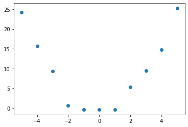

```python
import matplotlib.pyplot as plt
x = np.arange(-5, 6)
y = x**2 + np.random.normal(size=(len(x)))
plt.show(plt.scatter(x, y))
```

```python
import plotly.express as px
px.scatter(y=y, x=x)
```

[interactive chart not shown]

# Lets start with some data!

We're gonna predict the strain of grape plant that wine was made from!

But first a little bit of software. Python package manager is called pip. It is packaged by default with python. The recommended way of installing python is with [Anaconda](https://docs.anaconda.com/anaconda/install/). Furthermore, we will mainly use these two packages for our work here.

- [Scikit Learn](https://scikit-learn.org/stable/) - Library that has almost anything you could need for machine learning in python. Install with: `pip install scikit-learn`
- [Pandas](https://pandas.pydata.org/)- Very widely used library for handling data as tables. You'll see. Install with: `pip install pandas`

```python
# Scikit-learn and pandas, two core ML libraries
from sklearn.datasets import load_wine, load_iris
from sklearn.tree import DecisionTreeClassifier
from sklearn import tree
from sklearn.model_selection import train_test_split
import pandas as pd

# Three visualization libraries
import matplotlib.pyplot as plt
import seaborn as sns
import graphviz  # This is a python wrapper around a cli. It requires graphviz in your path.
```

## Now really some data

```python
wine_raw = load_wine(as_frame=True)
wine = wine_raw['frame']
print(wine_raw.target_names)
wine.sample(5)
```

```
['class_0' 'class_1' 'class_2']
```

|  | alcohol | malic_acid | ash | alcalinity_of_ash | magnesium | total_phenols | flavanoids | nonflavanoid_phenols | proanthocyanins | color_intensity | hue | od280/od315_of_diluted_wines | proline | target |
| --- | --- | --- | --- | --- | --- | --- | --- | --- | --- | --- | --- | --- | --- | --- |
| 48 | 14.10 | 2.02 | 2.40 | 18.8 | 103.0 | 2.75 | 2.92 | 0.32 | 2.38 | 6.20 | 1.07 | 2.75 | 1060.0 | 0 |
| 154 | 12.58 | 1.29 | 2.10 | 20.0 | 103.0 | 1.48 | 0.58 | 0.53 | 1.40 | 7.60 | 0.58 | 1.55 | 640.0 | 2 |
| 147 | 12.87 | 4.61 | 2.48 | 21.5 | 86.0 | 1.70 | 0.65 | 0.47 | 0.86 | 7.65 | 0.54 | 1.86 | 625.0 | 2 |
| 113 | 11.41 | 0.74 | 2.50 | 21.0 | 88.0 | 2.48 | 2.01 | 0.42 | 1.44 | 3.08 | 1.10 | 2.31 | 434.0 | 1 |
| 28 | 13.87 | 1.90 | 2.80 | 19.4 | 107.0 | 2.95 | 2.97 | 0.37 | 1.76 | 4.50 | 1.25 | 3.40 | 915.0 | 0 |

**data/independent variables**: All columns except the column we want to predict.

**target/dependent variable**: The thing we want to predict, so the `target` column. This value "depends" on the rest of the data.

## So lets train a machine learning model!

```python
# Accuracy: how many predictions were correct ->  sum(1=1, 2=2, 3=3)/total
dt = DecisionTreeClassifier(max_depth=2)
dt.fit(wine.drop('target', axis=1), wine.target)
print(f'Accuracy: {dt.score(wine.drop("target", axis=1), wine.target):.02f}')
```

```
Accuracy: 0.92
```

```python
sample = wine.sample(1)
print(f'Prediction: {dt.predict(sample.drop("target", axis=1)).item()}\nGround truth: {sample["target"].iloc[0]}')
```

```
Prediction: 1
Ground truth: 2
```

## Thanks for coming to my ted talk

## What is a Decision Tree?

Machine learning algorithm that splits on values of certain columns to predict answers. For example, what kind of contacts is someone wearing? Or, what strain of plant was used for a wine?

Why do we like this?

- Doesn't require a lot of feature engineering -> can use the data as is.
- Is very explainable and transparant.

[figure not shown]

```python
tree_viz
```

[figure not shown]

And we can show the importance of each feature

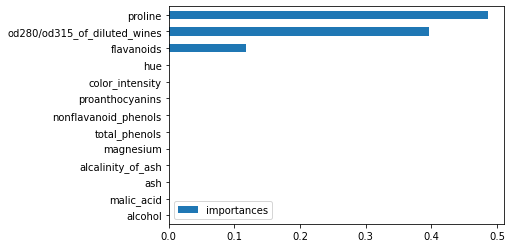

```python
(pd.DataFrame({'importances': dt.feature_importances_}, index=wine.drop('target', axis=1).columns)
     .sort_values('importances', ascending=True)
     .plot(kind='barh')
)
```

# Easy, right?

[figure not shown]

We might need to do a little due diligence.

## How do we know our model is any good?

Our model trains on all data and we are also evaluating using that data! That doens't work, the model has already seen that data! So we need a separate data set to evaluate our model.

We split our data into a *training set* and a *test set*. The *test set* is some percentage of the total data set. We will evaluate our model on the *test set*.

[figure not shown]

```python
x_train, x_test, y_train, y_test = train_test_split(wine.drop('target', axis=1), wine[['target']], test_size=0.2, shuffle=False)
```

```python
x_train.shape, y_train.shape, x_test.shape, y_test.shape
```

```
((142, 13), (142, 1), (36, 13), (36, 1))
```

```python
x_train.head(2)
```

|  | alcohol | malic_acid | ash | alcalinity_of_ash | magnesium | total_phenols | flavanoids | nonflavanoid_phenols | proanthocyanins | color_intensity | hue | od280/od315_of_diluted_wines | proline |
| --- | --- | --- | --- | --- | --- | --- | --- | --- | --- | --- | --- | --- | --- |
| 0 | 14.23 | 1.71 | 2.43 | 15.6 | 127.0 | 2.80 | 3.06 | 0.28 | 2.29 | 5.64 | 1.04 | 3.92 | 1065.0 |
| 1 | 13.20 | 1.78 | 2.14 | 11.2 | 100.0 | 2.65 | 2.76 | 0.26 | 1.28 | 4.38 | 1.05 | 3.40 | 1050.0 |

```python
y_train.head(2)
```

|  | target |
| --- | --- |
| 0 | 0 |
| 1 | 0 |

```python
dt = DecisionTreeClassifier(max_depth=2, random_state=8)
dt.fit(x_train, y_train)
print(f'Test set accuracy: {dt.score(x_test, y_test):.02f}')
```

```
Test set accuracy: 0.72
```

Oh no! Our accuracy dropped! So it performs a bit worse on data it has never seen.

Well, that ok, since it is still pretty high and we were only allowing the model to use two decisions.

**What if we allow it to do more?**

```python
dt = DecisionTreeClassifier(max_depth=3, random_state=8)
dt.fit(x_train, y_train)
print(f'Test set accuracy: {dt.score(x_test, y_test):.02f}')
```

```
Test set accuracy: 0.92
```

```python
dt = DecisionTreeClassifier(max_depth=5, random_state=8)
dt.fit(x_train, y_train)
print(f'Test set accuracy: {dt.score(x_test, y_test):.02f}')
```

```
Test set accuracy: 0.89
```

**Accuracy goes down!?**

```python
dot_data = tree.export_graphviz(dt, out_file=None,
                     feature_names=wine.drop('target', axis=1).columns,
                     class_names=wine_raw.target_names,
                     filled=True, rounded=True,
                     special_characters=True)
tree_viz = graphviz.Source(dot_data)
tree_viz
```

[figure not shown]

```
Test set accuracy with max depth of 1: 0.00
Test set accuracy with max depth of 2: 0.72
Test set accuracy with max depth of 3: 0.92
Test set accuracy with max depth of 5: 0.89
```

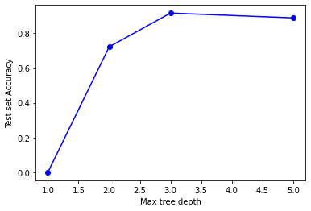

```python
accuracies = []
max_depths = [1, 2, 3, 5]
for max_depth in max_depths:
    dt = DecisionTreeClassifier(max_depth=max_depth, random_state=8)
    dt.fit(x_train, y_train)
    accuracy = dt.score(x_test, y_test)
    accuracies.append(accuracy)
    print(f'Test set accuracy with max depth of {max_depth}: {accuracy:.02f}')
plt.plot(max_depths, accuracies, 'bo-')
plt.xlabel('Max tree depth')
plt.ylabel('Test set Accuracy')
plt.show()
```

# Overfitting

A model or analysis that corresponds too closely or exactly with a particular set of data, and may therefor fail to generalize to new data points. The model is fitting to noise in the train set (not the thing we want to model).

[figure not shown]

We can try to prevent overfitting by:

1. Using more data (not always an option)
2. Reduce parameters in the model (Like reducing max depth)
3. Regularize the model (Like requiring multiple data points for each leaf-node)

# Stepping back a bit

We have seen:

1. What a decision tree is
2. What a train and test set are
3. What overfitting is

To give some extra context:

- This was a supervised machine learning problem
- It was a classification task

# Types of machine learning

1. **Supervised learning - We have labels (Strain of grape plant)**
2. Unsupervised learning - We don't have labels (We want to find similar data points)
3. Reinforcement learning - The algorithms learns from its own predictions (We want to play a game)

## Types of supervised learning:

1. **Classification** - Predict one of several classes. (Strain of grape plant, Animal, gender, etc.)
2. Regression - Predict a continuous value. (Price, weight, height, etc)

# Going a bit deeper: Random Forests

What other machine learning algorithms are there? We have the big brother of decision trees: random forests! They reduce the problem of overfitting of a single decision tree.

- Consist of a large number of individual decision trees (Ensemble)
- Are fit to a random subset of the training dataset (Boosted Aggregation, or bagging)
- Predict with the mode or mean of the predictions from each tree.

[figure not shown]

> "The low correlation between models is the key. Uncorrelated models can produce ensemble predictions that are more accurate than any of the individual predictions. (...) The reason for this wonderful effect is that the trees protect each other from their individual errors." - Tony Yiu ([Understanding Random Forests](https://towardsdatascience.com/understanding-random-forest-58381e0602d2))

```python
rfs = RandomForestClassifier(n_estimators=5, max_depth=2, random_state=9)
rfs.fit(x_train, y_train)
print('Test set acuraccy of decision tree with max-depth 2: 0.72')
print(f'Test set accuracy: {rfs.score(x_test, y_test):.02f}')
```

```
Test set acuraccy of decision tree with max-depth 2: 0.72
Test set accuracy: 0.89
```

```
Test set accuracy with 1 trees: 0.2778
Test set accuracy with 3 trees: 0.8889
Test set accuracy with 5 trees: 0.8889
Test set accuracy with 10 trees: 0.8056
```

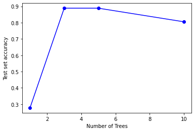

```python
accuracies = []
n_trees = [1, 3, 5, 10]
for n_tree in n_trees:
    rfs = RandomForestClassifier(n_estimators=n_tree, max_depth=3)
    rfs.fit(x_train, y_train.values.reshape(-1))
    accuracy = rfs.score(x_test, y_test)
    accuracies.append(accuracy)
    print(f'Test set accuracy with {n_tree} trees: {accuracy:.04f}')
plt.plot(n_trees, accuracies, 'bo-')
plt.xlabel('Number of Trees')
plt.ylabel('Test set accuracy')
plt.show()
```

# Lets make it a bit more interesting

This was only done on a very simple datasetand we have only looking at the modelling, and nothing else around.

[figure not shown]

The following example is from a course on ML from the University of San Fransisco. They have a great teacher, Jeremy Howard, who does really well code-first approached to machine learning and deep learning.

- Their lesson on this dataset is at https://github.com/fastai/fastai/blob/master/courses/ml1/lesson1-rf.ipynb.
- Find more of their work on fast.ai

```python
bulldozer_raw = pd.read_csv('train_sample.csv', parse_dates=['saledate'], low_memory=False)[:5000]
```

```python
display_all(bulldozer_raw[:30])
```

[output not shown]

## Bulldozer data

- From a kaggle challenge (https://www.kaggle.com/c/bluebook-for-bulldozers)
  - They give you the train data
  - They give you validation data **without** labels.
  - They give you test data only in the last week of the challenge.
  - They give you the target: predict the sale price of heavy machinery on a certain day
  - They give you the metric: The RMSLE (Root mean squared log error) between predicted price and actual price. $$\sqrt{\frac{1}{n}\sum_{i=1}^{n}(\log(y_i+1) - \log( \hat{y}_i+1))^{2}}$$

Now we have:

- Several data types (discrete, continuous, dates, NaNs)
- A continuous target (SalePrice)
- An interesting target, because the error (how wrong we are) is calculated with the log.

The key fields are in train.csv are:

- SalesID: the unique identifier of the sale
- MachineID: the unique identifier of a machine. A machine can be sold multiple times
- saleprice: what the machine sold for at auction (only provided in train.csv)
- saledate: the date of the sale

We need to:

- Preprocess the data
- Feature engineer the data. This means: how to we get suitable features (input for the model) from our data.

We take the log of the prices so we can just calculate the Root Mean Squared Error, which is a very commonly used metric.

The specific log here is the natural logarithm: $$ y' = \log_{e}(y) $$ where $e$ is the mathematical constant $e$)

```python
bulldozer_raw.SalePrice = np.log(bulldozer_raw.SalePrice)
bulldozer_raw.SalePrice
```

```
0       11.097410
1       10.950807
2        9.210340
3       10.558414
4        9.305651
          ...
4995    10.257659
4996     8.779557
4997     9.952278
4998    10.518673
4999    10.221941
Name: SalePrice, Length: 5000, dtype: float64
```

```python
rfs = RandomForestClassifier()
# This will fail due to mixed datatypes
rfs.fit(bulldozer_raw.drop('SalePrice', axis=1), bulldozer_raw.SalePrice)
```

[output not shown]

```python
for col in bulldozer_raw.columns.tolist():
    if bulldozer_raw[col].dtype == 'object':
        bulldozer_raw[col] = bulldozer_raw[col].astype('category')

with pd.option_context('display.max_rows', 100, 'display.max_columns', None):
    print(bulldozer_raw.dtypes)
```

```
SalesID                              int64
SalePrice                          float64
MachineID                            int64
ModelID                              int64
datasource                           int64
auctioneerID                       float64
YearMade                             int64
MachineHoursCurrentMeter           float64
UsageBand                         category
saledate                    datetime64[ns]
fiModelDesc                       category
fiBaseModel                       category
fiSecondaryDesc                   category
fiModelSeries                     category
fiModelDescriptor                 category
ProductSize                       category
fiProductClassDesc                category
state                             category
ProductGroup                      category
ProductGroupDesc                  category
Drive_System                      category
Enclosure                         category
Forks                             category
Pad_Type                          category
Ride_Control                      category
Stick                             category
Transmission                      category
Turbocharged                      category
Blade_Extension                   category
Blade_Width                       category
Enclosure_Type                    category
Engine_Horsepower                 category
Hydraulics                        category
Pushblock                         category
Ripper                            category
Scarifier                         category
Tip_Control                       category
Tire_Size                         category
Coupler                           category
Coupler_System                    category
Grouser_Tracks                    category
Hydraulics_Flow                   category
Track_Type                        category
Undercarriage_Pad_Width           category
Stick_Length                      category
Thumb                             category
Pattern_Changer                   category
Grouser_Type                      category
Backhoe_Mounting                  category
Blade_Type                        category
Travel_Controls                   category
Differential_Type                 category
Steering_Controls                 category
dtype: object
```

```python
bulldozer_raw.UsageBand.cat.categories
```

```
Index(['High', 'Low', 'Medium'], dtype='object')
```

```python
bulldozer_raw.UsageBand.cat.codes
```

```
0       2
1       2
2       0
3       0
4       1
       ..
4995   -1
4996    1
4997    2
4998   -1
4999    1
Length: 5000, dtype: int8
```

```python
bulldozer_raw.UsageBand.cat.set_categories(['High', 'Medium', 'Low'], ordered=True, inplace=True)
bulldozer_raw.UsageBand
```

[output not shown]

## Dates

Dates contain extremely much information. What kind of information could you get from a date?

- year, month and week

But also

- month begin/end, quarter begin/end, day of week

```python
??add_datepart
```

```
Object `add_datepart` not found.
```

```python
add_datepart(bulldozer_raw, 'saledate')
```

[output not shown]

5000 rows × 65 columns

```python
for col in bulldozer_raw.columns:
    if bulldozer_raw[col].dtype.name == 'category':
        bulldozer_raw[col] = bulldozer_raw[col].cat.codes
    if bulldozer_raw[col].dtype ==  'bool':
        bulldozer_raw[col] = bulldozer_raw[col].astype(int)
```

```python
# This is a regression problem (target is continuous), so we use a regressor instead of a classifier
from sklearn.ensemble import RandomForestRegressor
```

```python
x_train, x_test, y_train, y_test = train_test_split(bulldozer_raw.drop('SalePrice', axis=1), bulldozer_raw.SalePrice)
```

```python
rfs = RandomForestRegressor(n_estimators=10)
rfs.fit(x_train.values, y_train.values)
print(f'Test set R2: {rfs.score(x_test, y_test):.04f}')
```

```
Test set R2: 0.8193
```

In statistics, the coefficient of determination, denoted R2 or r2 and pronounced "R squared", is the proportion of the variance in the dependent variable that is predictable from the independent variable(s). https://en.wikipedia.org/wiki/Coefficient_of_determination

```python
preds = np.stack([t.predict(x_test) for t in rfs.estimators_])
preds[:,0], np.mean(preds[:,0]), y_test.iloc[0]
```

```
(array([ 9.472705, 10.275051, 11.302204, 10.778956,  9.798127,  9.581904, 10.23996 ,  9.711116,  9.798127,  9.798127]),
 10.075627695704647,
 9.305650551780507)
```

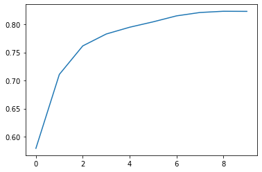

```python
from sklearn import metrics
plt.plot([metrics.r2_score(y_test, np.mean(preds[:i+1], axis=0)) for i in range(10)]);
```

# Thanks for attending!

# Now, on your way and go use ML!

[figure not shown]